# CV

Masatoshi Katabuchi

November 17, 2021

```r
library(tidyverse)
```

# 1 MVN version

## 1.1 Model

First, we foucs on the species means. Trait X (whole leaf LMA) for *i*th species is:
$$X_i \sim N(\mu, \sigma_x^2).$$

Trait Y (leaf disc LMA) for *i*th species is:

$$Y_i = X_i + \epsilon_i$$

where
$$\epsilon_i \sim N(0, \sigma_{\epsilon}^2)$$

**Q1: Do species mean of whole-leaf LMA and leaf disc LMA match well?**

This can be rephrased as testing the covariance between species mean of whole-leaf LMA and leaf disc LMA. (i.e., $\mathrm{Cov}(X_i, Y_i)$ ). This will be simple and it depends on $\sigma_y$.

Then, let’s look at the intraspecifc variation (ITV). Trait x and y for *j*th leaf of *i*th species are assumed to follow a multivariate normal distribution (MVN) because there should be positve covariances between the trait values with species (i.e., individual that has large x should have large y too).

$$\begin{bmatrix}
x_{ij} \\
y_{ij}
\end{bmatrix}
\sim MVN(
\begin{bmatrix}
\mu_{i} \\
\mu_{i}
\end{bmatrix}
,
\begin{bmatrix}
\sigma_{xi}^2 & \rho\sigma_{xi}\sigma_{yi} \\
\rho\sigma_{xi}\sigma_{yi} & \sigma_{yi}^2 \\
\end{bmatrix}
)$$

where $\mathrm{log}\sigma_{xi}$ and $\mathrm{log}\sigma_{yi}$ follow a MVN because there should be positive covariances between the extents of intraspecifc variation (i.e., species that have large ITV should have large ITV for both x and y traits).

$$\begin{bmatrix}
\mathrm{log}\sigma_{x i} \\
\mathrm{log}\sigma_{y i}
\end{bmatrix}
\sim MVN(
\begin{bmatrix}
\tau_{x} \\
\tau_{y}
\end{bmatrix}
,
\begin{bmatrix}
\hat{\sigma_{x}}^2 & \rho'\hat{\sigma_{x}}\hat{\sigma_{y}} \\
\rho'\hat{\sigma_{x}}\hat{\sigma_{y}} & \hat{\sigma_{y}}^2 \\
\end{bmatrix}
).$$

Alternatively, ITV can be written as:

$$x_{ij} \sim N(\mu_i, \sigma_{xi}^2)$$

$$y_{ij} = x_{ij} + \epsilon_{ij}$$

$$\epsilon_{ij} \sim N(0, \sigma_{\epsilon i}^2).$$

CV of trait x for *i*th species is:

$$CV_{xi} = \frac{\sigma_{xi}}{\mu_i}$$

or

$$CV = \sqrt{exp(\sigma_{xi}^2) - 1}.$$

**Q2: Does the extent of intraspecifc variation match between the whole-leaf and leaf disc estimates?**

This can be rephrased as testing the covariance between CV of LMA for each species estimated by whole-leaf and leaf disc. (i.e., $\mathrm{Cov}(CV_{x}, CV_{y})$ ).

## 1.2 Example

```r
cv <- \(x) sd(x)/mean(x)
cv_ln <- \(x) sqrt(exp(var(x)) - 1)
```

```r
set.seed(123)
# n: sp
n <- 100
# m: trees for each species
m <- 10

mu <- 5
sig_x <- 1
sig_e <- 0.5
tau_x <- -1
sig_tx_hat <- 0.3
tau_y <- -1
sig_ty_hat <- 0.5

x <- rnorm(n, mu, sig_x)
y <- x + rnorm(n, 0, sig_e^2)
```

```r
rho0 <- 0.3
S0 <- c(sig_tx_hat^2, rho0 * sig_tx_hat * sig_ty_hat,
    rho0 * sig_tx_hat * sig_ty_hat, sig_ty_hat^2) |>
    matrix(ncol = 2)

sig_t <- mvtnorm::rmvnorm(n, mean = c(tau_x, tau_y), sigma = S0) |>
  exp()
```

```r
rho <- 0.5
tmp <- NULL
for (i in 1:length(mu_i)) {
  S <- c(sig_t[i,1]^2, rho * sig_t[i,1] * sig_t[i,2],
    rho * sig_t[i,1] * sig_t[i,2], sig_t[i,2]^2) |>
    matrix(ncol = 2)
  tmp <- rbind(tmp, mvtnorm::rmvnorm(m, mean = rep(mu_i[i], 2), sigma = S))
}
colnames(tmp) <- c("x", "y")

trait <- tmp |>
  as_tibble() |>
  mutate(sp = rep(1:n, each = m)) |>
  mutate(tree = rep(1:m, n))

cv_dat <- trait |>
  group_by(sp) |>
  summarise_at(
               .vars = vars(x, y),
               .funs = cv)

cv_dat2 <- trait |>
  group_by(sp) |>
  summarise_at(
               .vars = vars(x, y),
               .funs = cv_ln)
```

Species mean.

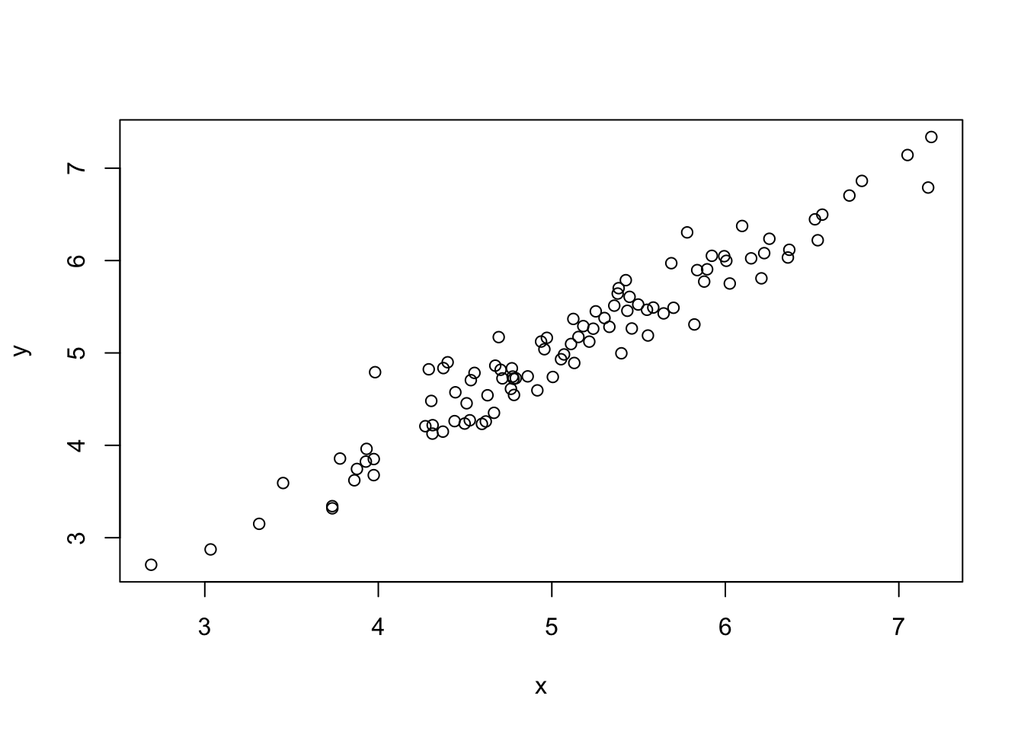

```r
plot(x, y)
```

```r
cor.test(x, y)
```

```
##
##  Pearson's product-moment correlation
##
## data:  x and y
## t = 36.935, df = 98, p-value < 2.2e-16
## alternative hypothesis: true correlation is not equal to 0
## 95 percent confidence interval:
##  0.9496600 0.9769723
## sample estimates:
##      cor
## 0.965907
```

Each tree.

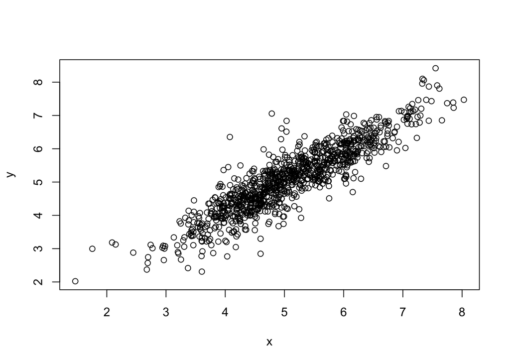

```r
plot(y ~ x, trait)
```

```r
cor.test(trait$y, trait$x)
```

```
##
##  Pearson's product-moment correlation
##
## data:  trait$y and trait$x
## t = 63.99, df = 998, p-value < 2.2e-16
## alternative hypothesis: true correlation is not equal to 0
## 95 percent confidence interval:
##  0.8838154 0.9081879
## sample estimates:
##       cor
## 0.8966791
```

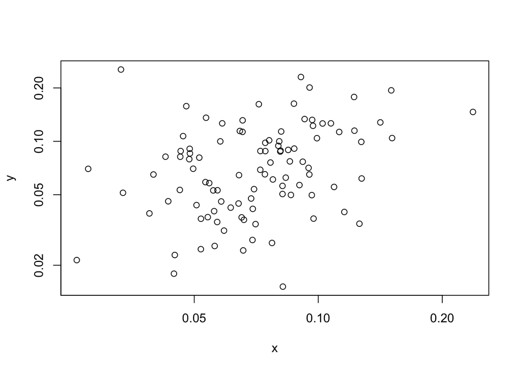

```r
plot(y ~ x, cv_dat, log = "xy")
```

```r
cor.test(log(cv_dat$y), log(cv_dat$x))
```

```
##
##  Pearson's product-moment correlation
##
## data:  log(cv_dat$y) and log(cv_dat$x)
## t = 3.3706, df = 98, p-value = 0.001074
## alternative hypothesis: true correlation is not equal to 0
## 95 percent confidence interval:
##  0.1344034 0.4878462
## sample estimates:
##       cor
## 0.3223127
```

## 1.3 Log-normal CV

$$CV = \sqrt{exp(\mathrm{V}|x|) - 1}$$

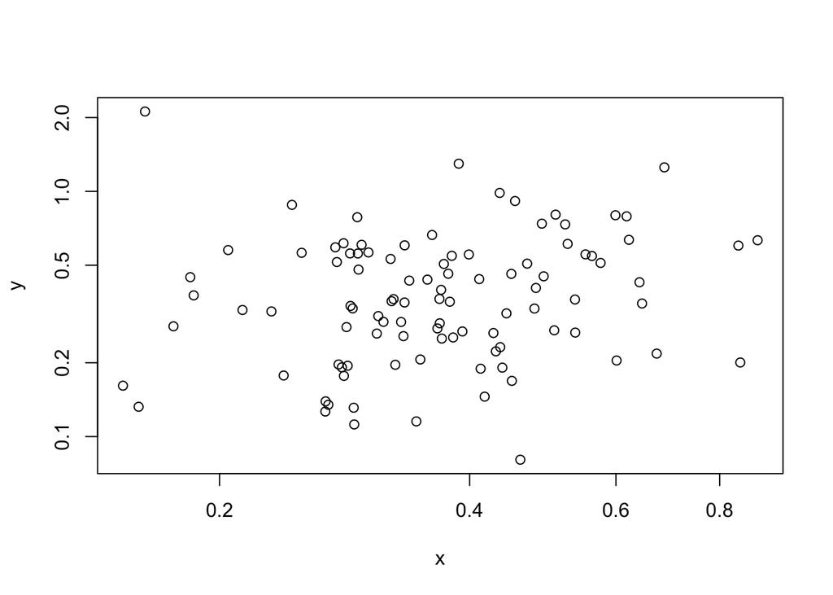

```r
plot(y ~ x, cv_dat2, log = "xy")
```

```r
cor.test(log(cv_dat2$y), log(cv_dat2$x))
```

```
##
##  Pearson's product-moment correlation
##
## data:  log(cv_dat2$y) and log(cv_dat2$x)
## t = 1.7399, df = 98, p-value = 0.08502
## alternative hypothesis: true correlation is not equal to 0
## 95 percent confidence interval:
##  -0.02413546  0.35737058
## sample estimates:
##       cor
## 0.1731033
```

# 2 Non-MVN version

## 2.1 Example

```r
set.seed(123)
# n: sp
n <- 100
# m: trees for each species
m <- 10

mu <- 5
sig_x <- 1
sig_tx_hat <- 0.3
tau_x <- -1
mu_i <- rnorm(n, mu, sig_x)
sig_tx <- rnorm(n, tau_x, sig_tx_hat) |> exp()
x <- mapply(rnorm, m, mu_i, sig_tx)

tau_e <- -0.2
sig_te_hat <- 0.1
sig_te <- rnorm(n, tau_e, sig_te_hat) |> exp()
e <- mapply(rnorm, m, 0, sig_te^2)

y <- x + e

x <- as.numeric(x)
y <- as.numeric(y)

trait <- tibble(x, y) |>
  mutate(sp = rep(1:n, each = m)) |>
  mutate(tree = rep(1:m, n))

cv_dat <- trait |>
  group_by(sp) |>
  summarise_at(
               .vars = vars(x, y),
               .funs = cv)

mean_dat <- trait |>
  group_by(sp) |>
  summarise_at(
               .vars = vars(x, y),
               .funs = mean)

cv_dat2 <- trait |>
  group_by(sp) |>
  summarise_at(
               .vars = vars(x, y),
               .funs = cv_ln)
```

Species mean.

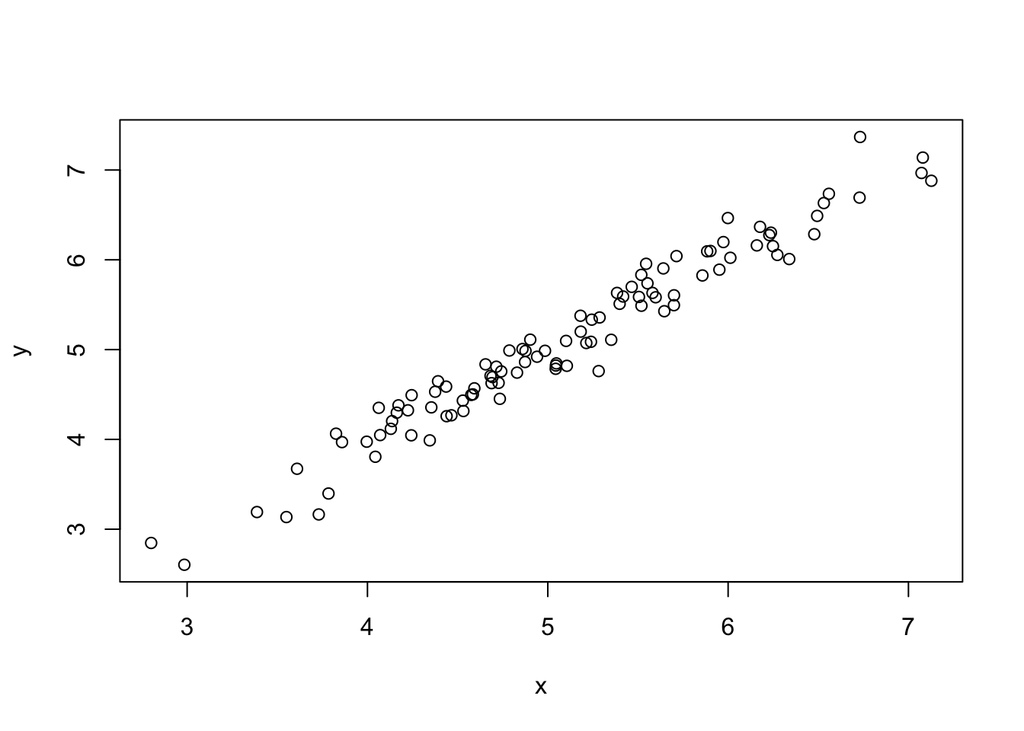

```r
plot(y ~ x, mean_dat)
```

```r
cor.test(mean_dat$y, mean_dat$x)
```

```
##
##  Pearson's product-moment correlation
##
## data:  mean_dat$y and mean_dat$x
## t = 46.109, df = 98, p-value < 2.2e-16
## alternative hypothesis: true correlation is not equal to 0
## 95 percent confidence interval:
##  0.9670079 0.9849805
## sample estimates:
##     cor
## 0.97772
```

Each tree.

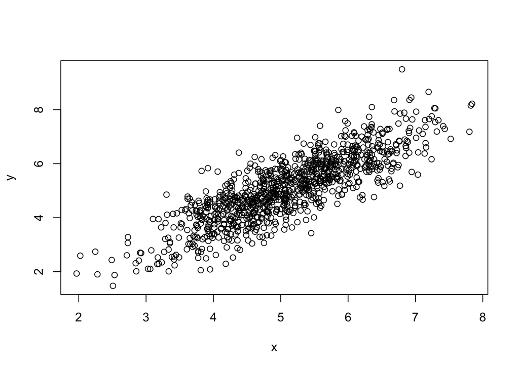

```r
plot(y ~ x, trait)
```

```r
cor.test(trait$y, trait$x)
```

```
##
##  Pearson's product-moment correlation
##
## data:  trait$y and trait$x
## t = 47.926, df = 998, p-value < 2.2e-16
## alternative hypothesis: true correlation is not equal to 0
## 95 percent confidence interval:
##  0.8151301 0.8527850
## sample estimates:
##       cor
## 0.8349321
```

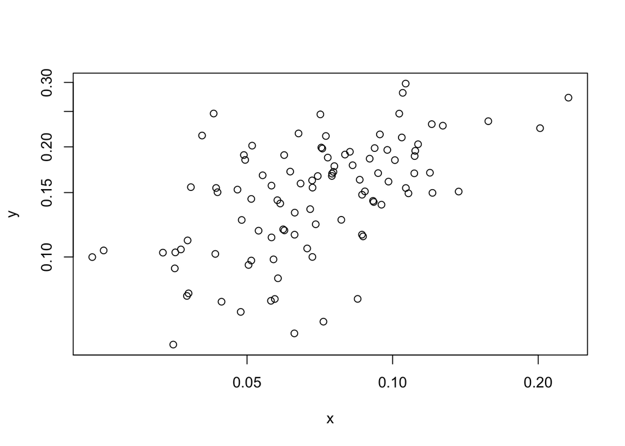

```r
plot(y ~ x, cv_dat, log = "xy")
```

```r
cor.test(log(cv_dat$y), log(cv_dat$x))
```

```
##
##  Pearson's product-moment correlation
##
## data:  log(cv_dat$y) and log(cv_dat$x)
## t = 6.6267, df = 98, p-value = 1.869e-09
## alternative hypothesis: true correlation is not equal to 0
## 95 percent confidence interval:
##  0.4039935 0.6785494
## sample estimates:
##       cor
## 0.5562706
```